# Sentiment Analysis

## Source

This analysis reproduces and extends examples from Chapter 2 of *Text Mining with R* by Julia Silge and David Robinson.

Silge, J., & Robinson, D. (2017). *Text Mining with R: A Tidy Approach*. O’Reilly Media.

## **Step2 — Extend The Analysis**

## **Using Different Text Corpus**

```r
#install.packages("gutenbergr")
library(gutenbergr)
library(tidytext)
library(dplyr)


gutenberg_metadata |>
  filter(str_detect(title, "Alice in Wonderland"))
```

```
# A tibble: 7 × 8
  gutenberg_id title     author gutenberg_author_id language gutenberg_bookshelf
         <int> <chr>     <chr>                <int> <fct>    <chr>
1          114 "The Ten… Tenni…                  74 en       ""
2        19551 "Alice i… Carro…                   7 en       "Category: Childre…
3        19551 "Alice i… Gorha…                8742 en       "Category: Childre…
4        35688 "Alice i… Carro…                   7 en       "Category: Childre…
5        35688 "Alice i… Gerst…               37837 en       "Category: Childre…
6        35990 "The Sto… Bowma…               38017 en       "Category: Biograp…
7        36308 "Songs F… Carro…                   7 en       "Category: Childre…
# ℹ 2 more variables: rights <fct>, has_text <lgl>
```

```r
alice <- gutenberg_download(11)
```

```
Mirror list unavailable. Falling back to <https://aleph.pglaf.org>.
```

#Analysis

```r
tidy_alice <- alice |>
  mutate(linenumber = row_number()) |>
  unnest_tokens(word, text)

alice_sentiment <- tidy_alice |>
  inner_join(get_sentiments("bing"), by = "word") |>
  count(sentiment)
```

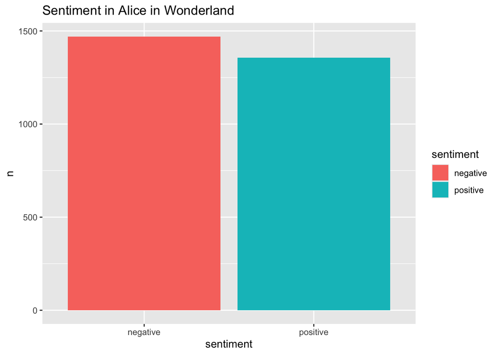

```r
library(ggplot2)
ggplot(alice_sentiment, aes(x = sentiment, y = n, fill = sentiment)) +
  geom_col() +
  labs(title = "Sentiment in Alice in Wonderland")
```

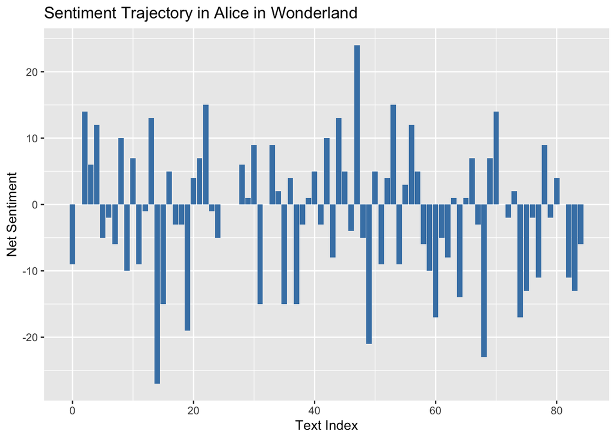

```r
alice_sentiment_time <- tidy_alice |>
  inner_join(get_sentiments("bing"), by = "word") |>
  count(index = linenumber %/% 80, sentiment) |>
  pivot_wider(names_from = sentiment, values_from = n, values_fill = 0) |>
  mutate(sentiment = positive - negative)

ggplot(alice_sentiment_time, aes(x = index, y = sentiment)) +
  geom_col(fill = "steelblue") +
  labs(
    title = "Sentiment Trajectory in Alice in Wonderland",
    x = "Text Index",
    y = "Net Sentiment"
  )
```

## **Using one new lexicon for analysis**

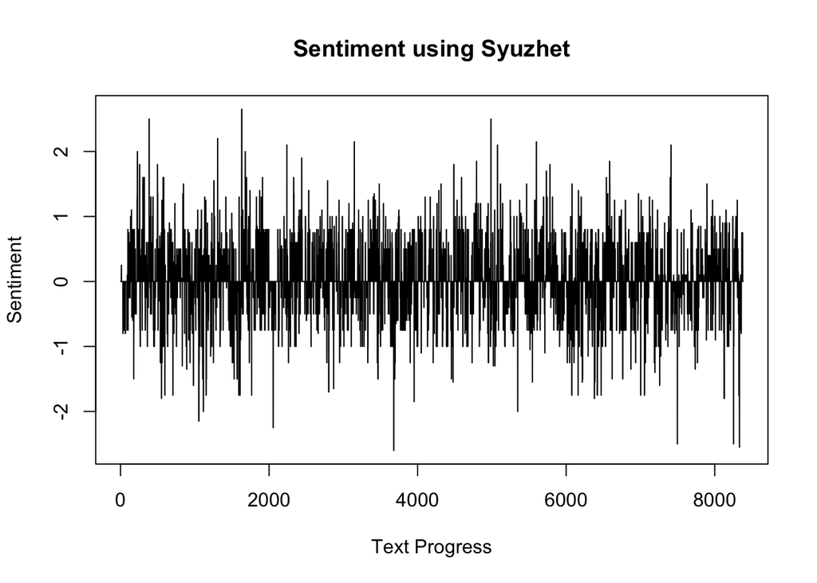

```r
#install.packages("syuzhet")
library(syuzhet)

# split text into sentences automatically
sentences <- get_sentences(alice$text)
sentiment_values <- get_sentiment(sentences)

plot(sentiment_values, type = "l",
     main = "Sentiment using Syuzhet",
     ylab = "Sentiment",
     xlab = "Text Progress")
```

Using the *syuzhet* package, I analyzed sentiment at the sentence level, which produces a continuous sentiment trajectory across the text. Unlike the Bing, AFINN, and NRC lexicons, which rely on word-level classifications, this method captures how sentiment evolves throughout the narrative. The results show fluctuations in sentiment that reflect changes in tone and events within the story.

The Bing lexicon classifies words strictly as positive or negative, which provides a simple overall sentiment score. In contrast, the Syuzhet method evaluates sentiment at the sentence level and produces a continuous sentiment score. This allows for a more detailed view of how sentiment changes throughout the narrative, rather than just counting positive and negative words.

## Conclusion

This assignment was both challenging and informative. By reproducing and extending the sentiment analysis example from Chapter 2, I learned how to work with text data, apply different sentiment lexicons, and visualize patterns in language.

Using Alice’s Adventures in Wonderland as an alternative corpus, I observed that sentiment patterns vary significantly depending on the structure and style of the text. The Bing lexicon provided a simple classification of positive and negative words, while the Syuzhet method offered a more detailed view of how sentiment evolves throughout the narrative.

Overall, this project improved my understanding of text mining, sentiment analysis, and data visualization in R, and demonstrated how different analytical approaches can lead to different insights.